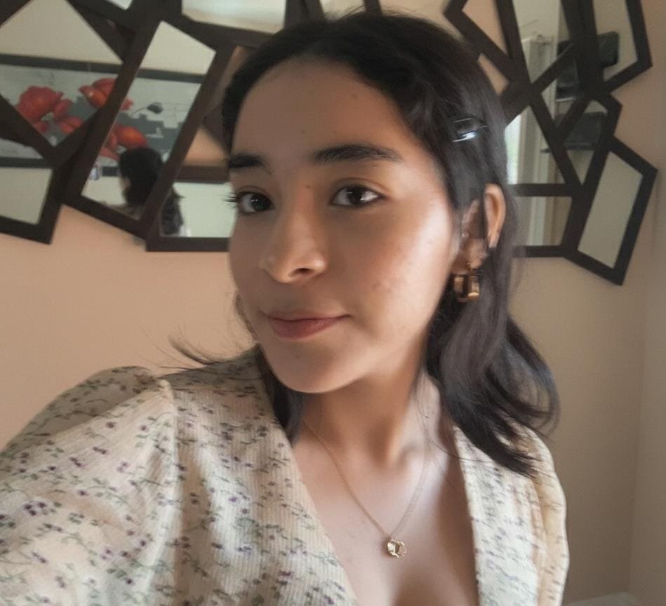

# Jahzeel Palafox

🧬 Estudiante de Ciencias Genómicas

🏛️ Universidad Nacional Autónoma de México

## Sobre mí

Soy estudiante de la Licenciatura en Ciencias Genómicas con un interés profundo en integrar biología y ciencias de datos desde una base teórica sólida.

Me atrae especialmente el análisis computacional aplicado a datos biológicos, la optimización combinatoria y los fundamentos teóricos que sustentan la bioinformática y la genómica moderna.

## Formación en desarrollo

- **Ciencias de la Computación:** Estructuras de datos, diseño y análisis de algoritmos, programación en C y Python.
- **Matemáticas Aplicadas:** Matemáticas discretas, lógica formal, probabilidad y modelado de sistemas biológicos.
- **Bioinformática y Estadística:** Análisis de datos genómicos en R y Bioconductor, métodos de inferencia estadística.
- **Genómica y Sistemas Biológicos:** Organización y dinámica de genomas, mecanismos moleculares de herencia y variación, integración y modelado de redes biológicas.

## Enfoque personal

Soy una persona introspectiva y profundamente curiosa. Disfruto pensar con calma, desarmar problemas y reconstruirlos con claridad.

Soy disciplinada y exigente conmigo misma, pero también consciente de que el aprendizaje es un proceso continuo. Prefiero la profundidad a la rapidez y la coherencia a la improvisación.

Para mí, los datos y los algoritmos son herramientas; lo verdaderamente importante es comprender la vida con responsabilidad y sensibilidad.

Aspiro a convertirme en una científica sólida en fundamentos, creativa en pensamiento y humana en práctica.